# Project

2024-02-29

```r
#make a new column which categorises the type of natural disaster as direct effetc of climate hcange, indirect effetc of climate chnage and not related

# Define vectors of natural disasters classified as primary and secondary effects of climate change
primary_effects <- c("Extreme temperature", "Flood", "Storm")
secondary_effects <- c("Glacial lake outburst flood", "Drought", "Wildfire",  "Mass movement (wet)", " Mass movement (dry)")

# Create a new column indicating the effect of the natural disaster related to climate change
full_data <- updated_data %>%
  mutate(climate_change_effect = case_when(
    updated_data$type %in% primary_effects ~ "Primary effect",
    updated_data$type  %in% secondary_effects ~ "Secondary effect",
    TRUE ~ "Not related"
  ))

full_data
```

```
## # A tibble: 9,505 × 16
##    historic id         classification group subgroup type  subtype iso   country
##    <chr>    <chr>      <chr>          <chr> <chr>    <chr> <chr>   <chr> <chr>
##  1 No       1999-9388… nat-cli-dro-d… Natu… Climato… Drou… Drought DJI   Djibou…
##  2 No       1999-9388… nat-cli-dro-d… Natu… Climato… Drou… Drought SDN   Sudan
##  3 No       1999-9388… nat-cli-dro-d… Natu… Climato… Drou… Drought SOM   Somalia
##  4 No       2000-0002… nat-hyd-flo-r… Natu… Hydrolo… Flood Riveri… AGO   Angola
##  5 No       2000-0003… nat-met-ext-c… Natu… Meteoro… Extr… Cold w… BGD   Bangla…
##  6 No       2000-0008… nat-geo-vol-a… Natu… Geophys… Volc… Ash fa… GTM   Guatem…
##  7 No       2000-0009… nat-met-sto-s… Natu… Meteoro… Storm Storm … IRN   Iran (…
##  8 No       2000-0012… nat-hyd-flo-r… Natu… Hydrolo… Flood Riveri… MOZ   Mozamb…
##  9 No       2000-0017… nat-cli-wil-l… Natu… Climato… Wild… Land f… ZAF   South …
## 10 No       2000-0019… nat-hyd-flo-r… Natu… Hydrolo… Flood Riveri… BRA   Brazil
## # ℹ 9,495 more rows
## # ℹ 7 more variables: subregion <chr>, region <chr>, location <chr>,
## #   year <dbl>, month <dbl>, day <dbl>, climate_change_effect <chr>
```

## Data Origins

The data set comes from the **Centre for Research on the Epidemiology of Disasters (CRED)**. This organisation records every instances of natural disasters since 1900 within the EM-DAT database. This comprehensive open source database complies data from various sources; UN agencies, government agencies, research centers, humanitarian organisations, reinsurance companies and world press agencies. For a full list of sources see the [EM-DAT website](https://doc.emdat.be/docs/data-structure-and-content/emdat-sources/). I chose to download all the information regarding natural disasters between the year 1922 and 2022 totaling 16388 disasters. After looking at the data it was clear that the historic record before 2000 was too sparse to stand up against the quality of data recording conducted by CRED since its inception in 2000. Rather than looking at changes over a century using the historic record I have decided to focus on non historic entries of natural disasters which have occurred since 2000. Natural disaster between the year 2000 and 2022 totals 9505.

## Research Questions

- Has there been a change in prevalence of natural disasters types since the year 2000? Particularly has there been an increase in natural disaster related to climate change eg flooding?
- What countries or region have experienced the most natural disasters since the year 2000?
- Has there been a difference in the occurrence of natural disasters per region since the year 2000, for example did North America experience more natural disasters in a particular year?

## Variables

To answer my research questions I am interested in where and when different natural disasters occurred. The following variables are of potential interest in asking these questions:

*for further explanation of each variable see the [codebook](https://doc.emdat.be/docs/data-structure-and-content/emdat-public-table/) provided by the EM-DATA database*

```r
#summary of number of disaster per subgroup
full_data %>% group_by(subgroup) %>% summarise(count = n())
```

```
## # A tibble: 6 × 2
##   subgroup          count
##   <chr>             <int>
## 1 Biological          910
## 2 Climatological      678
## 3 Extra-terrestrial     1
## 4 Geophysical         760
## 5 Hydrological       4275
## 6 Meteorological     2881
```

```r
#summary of number of disasters per subgroup per type
full_data %>% group_by(subgroup, type) %>% summarise(count = n())
```

```
## # A tibble: 14 × 3
## # Groups:   subgroup [6]
##    subgroup          type                        count
##    <chr>             <chr>                       <int>
##  1 Biological        Animal incident                 1
##  2 Biological        Epidemic                      880
##  3 Biological        Infestation                    29
##  4 Climatological    Drought                       393
##  5 Climatological    Glacial lake outburst flood     3
##  6 Climatological    Wildfire                      282
##  7 Extra-terrestrial Impact                          1
##  8 Geophysical       Earthquake                    626
##  9 Geophysical       Mass movement (dry)            13
## 10 Geophysical       Volcanic activity             121
## 11 Hydrological      Flood                        3852
## 12 Hydrological      Mass movement (wet)           423
## 13 Meteorological    Extreme temperature           479
## 14 Meteorological    Storm                        2402
```

```r
#summary of number of disasters per subtype
full_data %>% group_by(subtype) %>% summarise(count = n())
```

```
## # A tibble: 45 × 2
##    subtype               count
##    <chr>                 <int>
##  1 Animal incident           1
##  2 Ash fall                 99
##  3 Avalanche (dry)           1
##  4 Avalanche (wet)          47
##  5 Bacterial disease       413
##  6 Blizzard/Winter storm   174
##  7 Coastal flood            41
##  8 Cold wave               219
##  9 Collision                 1
## 10 Derecho                   6
## # ℹ 35 more rows
```

```r
# this variable may be to specific for the scope of my question


#summary of number of disasters per region
full_data %>% group_by(region) %>% summarise(count = n())
```

```
## # A tibble: 5 × 2
##   region   count
##   <chr>    <int>
## 1 Africa    2032
## 2 Americas  2180
## 3 Asia      3703
## 4 Europe    1232
## 5 Oceania    358
```

```r
#summary of number of disasters per region per subregion
full_data %>% group_by(region, country) %>% summarise(count = n())
```

```
## # A tibble: 218 × 3
## # Groups:   region [5]
##    region country                  count
##    <chr>  <chr>                    <int>
##  1 Africa Algeria                     49
##  2 Africa Angola                      63
##  3 Africa Benin                       31
##  4 Africa Botswana                    13
##  5 Africa Burkina Faso                36
##  6 Africa Burundi                     53
##  7 Africa Cabo Verde                   9
##  8 Africa Cameroon                    36
##  9 Africa Canary Islands               6
## 10 Africa Central African Republic    36
## # ℹ 208 more rows
```

```r
#summary of number of disaster per year
full_data %>% group_by(year, region) %>% summarise(count = n())
```

```
## # A tibble: 115 × 3
## # Groups:   year [23]
##     year region   count
##    <dbl> <chr>    <int>
##  1  2000 Africa     125
##  2  2000 Americas   101
##  3  2000 Asia       193
##  4  2000 Europe      94
##  5  2000 Oceania     12
##  6  2001 Africa     116
##  7  2001 Americas    95
##  8  2001 Asia       164
##  9  2001 Europe      52
## 10  2001 Oceania     19
## # ℹ 105 more rows
```

[figure not shown]

[figure not shown]

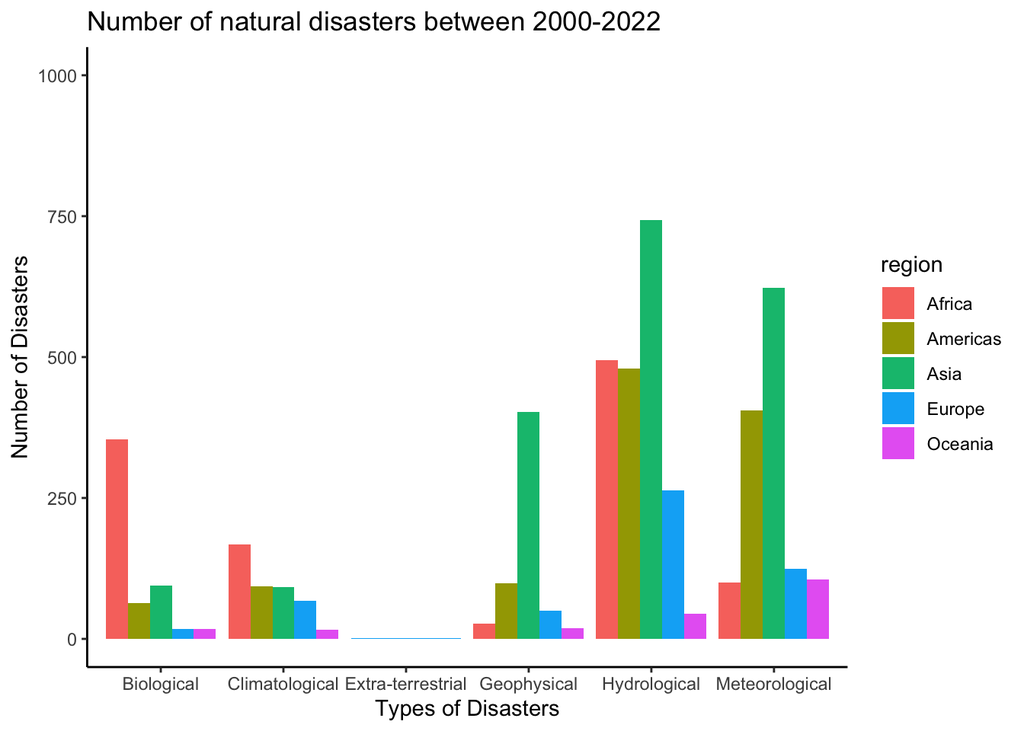

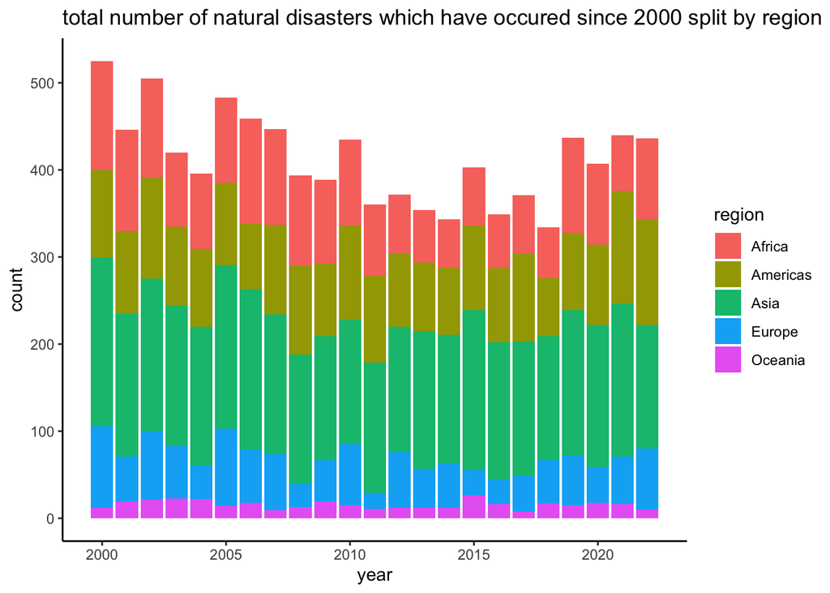

```r
view(full_data)
```

- Has there been a change in prevalence of natural disasters types since the year 2000? Particularly has there been an increase in natural disaster related to climate change e.g. flooding?

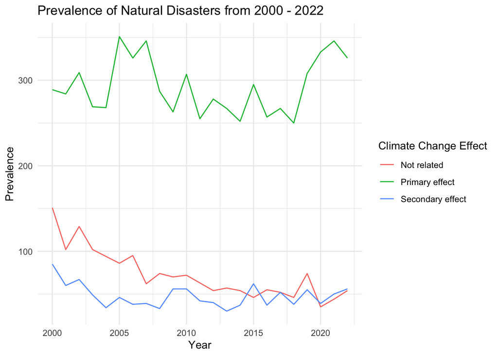

```r
#want a line graph which charts changes in prevalence over time split by the 3 conditions.
# graph where x is years, y is prevalance

 ggplot(full_data, aes(x = year, y = after_stat(count), color = climate_change_effect)) +
  geom_line(stat = "count") +
  labs(x = "Year", y = "Prevalence", color = "Climate Change Effect") +
  ggtitle("Prevalence of Natural Disasters from 2000 - 2022") +
  theme_minimal()
```

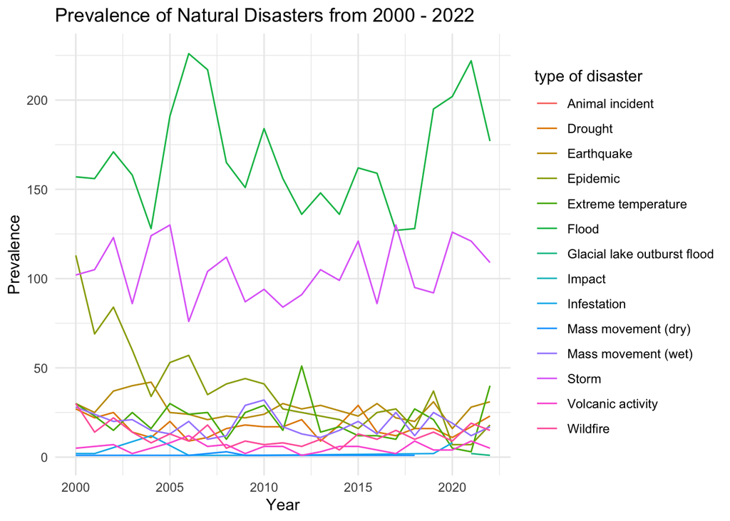

```r
#exploring extra

 ggplot(full_data, aes(x = year, y = after_stat(count), color = type)) +
  geom_line(stat = "count") +
  labs(x = "Year", y = "Prevalence", color = "type of disaster") +
  ggtitle("Prevalence of Natural Disasters from 2000 - 2022") +
  theme_minimal()
```

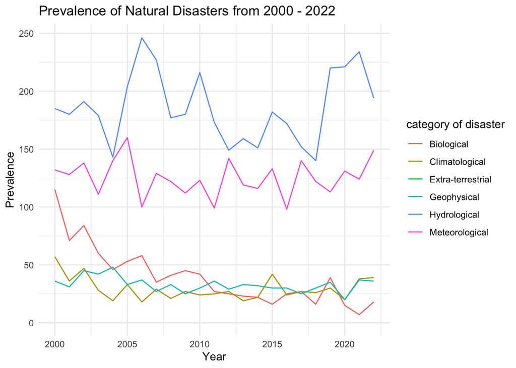

```r
  ggplot(full_data, aes(x = year, y = after_stat(count), color = subgroup)) +
  geom_line(stat = "count") +
  labs(x = "Year", y = "Prevalence", color = "category of disaster") +
  ggtitle("Prevalence of Natural Disasters from 2000 - 2022") +
  theme_minimal()
```

- What countries or region have experienced the most natural disasters since the year 2000? Has this changed over time? graph of the world which shows total natural disasters on an atlas - or show how it changes over last 20 years - animated.

```r
# i need the latitude and longitude of every country so i can map it


world1 <- map_data("worldHires")
head(world1)
```

```
##        long      lat group order region subregion
## 1 -133.3664 58.42416     1     1 Canada      <NA>
## 2 -133.3686 58.42336     1     2 Canada      <NA>
## 3 -133.3878 58.41196     1     3 Canada      <NA>
## 4 -133.4089 58.40027     1     4 Canada      <NA>
## 5 -133.4281 58.38864     1     5 Canada      <NA>
## 6 -133.4472 58.37724     1     6 Canada      <NA>
```

```r
#now have long and lat for every country. what i need is consistency between the naming of 'region' and naming of 'country' in my dataset

#it might be a good idea to make everything lowercase

#now you need to identify which countries are written differently

#correct for the inconsistency



# Load your dataset containing countries (replace 'your_dataset.csv' with your actual dataset)
full_data
```

```
## # A tibble: 9,505 × 16
##    historic id         classification group subgroup type  subtype iso   country
##    <chr>    <chr>      <chr>          <chr> <chr>    <chr> <chr>   <chr> <chr>
##  1 No       1999-9388… nat-cli-dro-d… Natu… Climato… Drou… Drought DJI   Djibou…
##  2 No       1999-9388… nat-cli-dro-d… Natu… Climato… Drou… Drought SDN   Sudan
##  3 No       1999-9388… nat-cli-dro-d… Natu… Climato… Drou… Drought SOM   Somalia
##  4 No       2000-0002… nat-hyd-flo-r… Natu… Hydrolo… Flood Riveri… AGO   Angola
##  5 No       2000-0003… nat-met-ext-c… Natu… Meteoro… Extr… Cold w… BGD   Bangla…
##  6 No       2000-0008… nat-geo-vol-a… Natu… Geophys… Volc… Ash fa… GTM   Guatem…
##  7 No       2000-0009… nat-met-sto-s… Natu… Meteoro… Storm Storm … IRN   Iran (…
##  8 No       2000-0012… nat-hyd-flo-r… Natu… Hydrolo… Flood Riveri… MOZ   Mozamb…
##  9 No       2000-0017… nat-cli-wil-l… Natu… Climato… Wild… Land f… ZAF   South …
## 10 No       2000-0019… nat-hyd-flo-r… Natu… Hydrolo… Flood Riveri… BRA   Brazil
## # ℹ 9,495 more rows
## # ℹ 7 more variables: subregion <chr>, region <chr>, location <chr>,
## #   year <dbl>, month <dbl>, day <dbl>, climate_change_effect <chr>
```

```r
    # Extract unique countries  from your dataset
unique_disaster <- unique(full_data$country)

# extract unique country from world data
unique_world <- unique(world1$region)

# Check for matching ISO codes
matching_codes <- unique_disaster %in% unique_world

# Print out the results
print(matching_codes)
```

```
##   [1]  TRUE  TRUE  TRUE  TRUE  TRUE  TRUE FALSE  TRUE  TRUE  TRUE  TRUE FALSE
##  [13]  TRUE  TRUE  TRUE FALSE  TRUE  TRUE  TRUE FALSE  TRUE  TRUE  TRUE FALSE
##  [25]  TRUE  TRUE FALSE  TRUE  TRUE  TRUE  TRUE  TRUE  TRUE  TRUE  TRUE FALSE
##  [37]  TRUE  TRUE  TRUE  TRUE  TRUE  TRUE  TRUE  TRUE FALSE  TRUE FALSE  TRUE
##  [49]  TRUE  TRUE  TRUE  TRUE FALSE  TRUE  TRUE  TRUE FALSE  TRUE FALSE FALSE
##  [61]  TRUE  TRUE  TRUE  TRUE FALSE  TRUE FALSE FALSE FALSE  TRUE  TRUE  TRUE
##  [73]  TRUE  TRUE FALSE  TRUE FALSE  TRUE  TRUE  TRUE FALSE  TRUE  TRUE  TRUE
##  [85] FALSE  TRUE  TRUE  TRUE  TRUE  TRUE  TRUE  TRUE  TRUE  TRUE  TRUE FALSE
##  [97]  TRUE FALSE  TRUE  TRUE FALSE FALSE  TRUE  TRUE  TRUE  TRUE  TRUE FALSE
## [109]  TRUE FALSE  TRUE FALSE FALSE  TRUE  TRUE FALSE  TRUE FALSE  TRUE FALSE
## [121] FALSE  TRUE  TRUE  TRUE  TRUE  TRUE  TRUE FALSE FALSE FALSE  TRUE  TRUE
## [133] FALSE  TRUE  TRUE  TRUE  TRUE FALSE FALSE  TRUE FALSE  TRUE  TRUE  TRUE
## [145]  TRUE  TRUE  TRUE  TRUE  TRUE FALSE  TRUE  TRUE  TRUE  TRUE  TRUE  TRUE
## [157] FALSE  TRUE  TRUE  TRUE FALSE FALSE  TRUE  TRUE  TRUE  TRUE FALSE  TRUE
## [169] FALSE  TRUE FALSE  TRUE  TRUE  TRUE  TRUE FALSE  TRUE FALSE FALSE  TRUE
## [181] FALSE FALSE  TRUE FALSE FALSE  TRUE  TRUE  TRUE  TRUE FALSE  TRUE  TRUE
## [193]  TRUE  TRUE  TRUE  TRUE FALSE  TRUE FALSE FALSE FALSE  TRUE FALSE FALSE
## [205]  TRUE  TRUE FALSE FALSE  TRUE  TRUE FALSE FALSE FALSE FALSE  TRUE  TRUE
## [217]  TRUE  TRUE
```

```r
# Extract the indices where matching_codes is FALSE
mismatch_indices <- which(!matching_codes)

# Extract the specific countries  that do not match
mismatched_disaster_spelling <- unique_disaster [!matching_codes]

# Print out the mismatched
print(mismatched_disaster_spelling )
```

```
##  [1] "Iran (Islamic Republic of)"
##  [2] "United States of America"
##  [3] "Réunion"
##  [4] "Russian Federation"
##  [5] "United Republic of Tanzania"
##  [6] "Bosnia and Herzegovina"
##  [7] "Eswatini"
##  [8] "Democratic Republic of the Congo"
##  [9] "Bolivia (Plurinational State of)"
## [10] "Czechia"
## [11] "Türkiye"
## [12] "Republic of Korea"
## [13] "Serbia Montenegro"
## [14] "Kazakhstan"
## [15] "Micronesia (Federated States of)"
```

[output cut: 52 more lines]

```r
mismatched_world_spelling <- unique_world [!matching_codes]
print(mismatched_world_spelling)
```

```
##  [1] "Aral Sea"               "Mexico"                 "USA"
##  [4] "France"                 "Honduras"               "Panama"
##  [7] "Uruguay"                "Iran"                   "Afghanistan"
## [10] "Bangladesh"             "Vietnam"                "Hungary"
## [13] "Czechoslovakia"         "Bulgaria"               "Greece"
## [16] "Albania"                "Austria"                "Portugal"
## [19] "UK"                     "Finland"                "Sudan"
## [22] "Ivory Coast"            "Sierra Leone"           "Niger"
## [25] "Benin"                  "Congo"                  "Equatorial Guinea"
## [28] "Uganda"                 "Rwanda"                 "Namibia"
## [31] "Mozambique"             "Zimbabwe"               "Malawi"
## [34] "Jordan"                 "Israel"                 "Gaza Strip"
## [37] "Qatar"                  "Lake Tanganyika"        "Lake Kariba"
## [40] "Oman"                   "Antarctica"             "Saint-Barthelemy"
## [43] "South Sandwich Islands" "Guadeloupe"             "Nauru"
## [46] "Tonga"                  "Vanuatu"                "Sicily"
## [49] "Haiti"                  "Madagascar"             "Sonsorol Island"
## [52] "New Caledonia"          "Bahamas"                "Tokelau"
## [55] "Saint Eustatius"        "Seychelles"             "San Marino"
## [58] "Sin Cowe Island"        "Tuvalu"                 "Sao Tome and Principe"
## [61] "Tobago"                 "Falkland Islands"       "Samoa"
## [64] "Grenada"                "Cayman Islands"         "Virgin Islands"
## [67] "Canary Islands"         "Spratly Island"         "Aruba"
## [70] "Saint-Martin"
```

```r
up_data <- full_data %>%
  mutate(country = recode(country,
                          "Iran (Islamic Republic of)" = "Iran",
                          "United States of America" = "USA",
                          "Réunion"  =  "Reunion",
                          "Russian Federation"  = "Russia",
                          "Congo"  = "Republic of Congo",
                          "United Republic of Tanzania"  = "Tanzania",
                          "Eswatini" = "Swaziland",
                          "Bolivia (Plurinational State of)" = "Bolivia",
                          "Czechia"  = "Czech Republic",
                          "Türkiye" =  "Turkey",
                          "Republic of Korea"  = "South Korea",
                          "Serbia Montenegro"  =  "Montenegro",
                          "Micronesia (Federated States of)" = "Micronesia",
                          "United Kingdom of Great Britain and Northern Ireland" = "UK",
                          "Viet Nam"    = "Vietnam",
                          "Lao People's Democratic Republic"   = "Laos",
                          "Taiwan (Province of China)" = "Taiwan",
                          "Democratic People's Republic of Korea" = "North Korea",
                          "Venezuela (Bolivarian Republic of)"  = "Venezuela",
                          "Republic of Moldova"   = "Moldova",
                          "Syrian Arab Republic"    = "Syria",
                          "Côte d’Ivoire"      =   "Ivory Coast",
                          "Saint Vincent and the Grenadines"= "Saint Vincent",
                          "Netherlands (Kingdom of the)" = "Netherlands" ,
                          "China, Hong Kong Special Administrative Region"   = "China" ,
                          "China, Macao Special Administrative Region"      = "China",
                          "Cabo Verde"  = "Cape Verde",
                          "United States Virgin Islands"   = "Virgin Islands",

                          "State of Palestine"    = "Palestine",
                         "Saint Kitts and Nevis"    = "Saint Kitts",
                          "Wallis and Futuna Islands"  = "Wallis and Futuna",
                          "Saint Barthélemy"     = "Saint Barthelemy",
                          "Saint Martin (French Part)"  = "Saint Martin",
                          "Sint Maarten (Dutch part)"  = "Saint Martin",
                          "British Virgin Islands"     = "Virgin Islands" ))

#







up_unique_disaster <- unique(up_data$country)

# extract unique country from world data
unique_world <- unique(world1$region)

# Check for matching ISO codes
up_matching_codes <- up_unique_disaster %in% unique_world

# Print out the results
print(up_matching_codes)
```

```
##   [1]  TRUE  TRUE  TRUE  TRUE  TRUE  TRUE  TRUE  TRUE  TRUE  TRUE  TRUE  TRUE
##  [13]  TRUE  TRUE  TRUE FALSE  TRUE  TRUE  TRUE FALSE FALSE  TRUE  TRUE  TRUE
##  [25]  TRUE  TRUE FALSE  TRUE  TRUE  TRUE  TRUE  TRUE  TRUE  TRUE  TRUE  TRUE
##  [37]  TRUE  TRUE  TRUE  TRUE  TRUE  TRUE  TRUE  TRUE FALSE  TRUE  TRUE  TRUE
##  [49]  TRUE  TRUE  TRUE  TRUE FALSE  TRUE  TRUE  TRUE  TRUE  TRUE  TRUE FALSE
##  [61]  TRUE  TRUE  TRUE  TRUE FALSE  TRUE  TRUE  TRUE FALSE  TRUE  TRUE  TRUE
##  [73]  TRUE  TRUE FALSE  TRUE FALSE  TRUE  TRUE  TRUE  TRUE  TRUE  TRUE  TRUE
##  [85]  TRUE  TRUE  TRUE  TRUE  TRUE  TRUE  TRUE  TRUE  TRUE  TRUE  TRUE  TRUE
##  [97]  TRUE FALSE  TRUE  TRUE FALSE  TRUE  TRUE  TRUE  TRUE  TRUE  TRUE FALSE
## [109]  TRUE  TRUE  TRUE FALSE FALSE  TRUE  TRUE FALSE  TRUE FALSE  TRUE FALSE
## [121] FALSE  TRUE  TRUE  TRUE  TRUE  TRUE  TRUE FALSE FALSE FALSE  TRUE  TRUE
## [133]  TRUE  TRUE  TRUE  TRUE  TRUE FALSE FALSE  TRUE  TRUE  TRUE  TRUE  TRUE
## [145]  TRUE  TRUE  TRUE  TRUE  TRUE FALSE  TRUE  TRUE  TRUE  TRUE  TRUE  TRUE
## [157] FALSE  TRUE  TRUE  TRUE  TRUE  TRUE  TRUE  TRUE  TRUE  TRUE  TRUE  TRUE
## [169]  TRUE  TRUE  TRUE  TRUE  TRUE FALSE  TRUE FALSE FALSE  TRUE FALSE FALSE
## [181]  TRUE FALSE  TRUE  TRUE  TRUE  TRUE  TRUE FALSE  TRUE  TRUE  TRUE  TRUE
## [193]  TRUE  TRUE FALSE  TRUE FALSE FALSE  TRUE FALSE  TRUE  TRUE  TRUE FALSE
## [205] FALSE  TRUE  TRUE FALSE FALSE  TRUE  TRUE  TRUE  TRUE
```

```r
# Extract the indices where matching_codes is FALSE
up_mismatch_indices <- which(!up_matching_codes)

# Extract the specific countries  that do not match
up_mismatched_disaster_spelling <- up_unique_disaster [!up_matching_codes]

# Print out the mismatched
print(up_mismatched_disaster_spelling )
```

```
##  [1] "Reunion"                          "Russia"
##  [3] "Republic of Congo"                "Bosnia and Herzegovina"
##  [5] "Democratic Republic of the Congo" "Czech Republic"
##  [7] "Montenegro"                       "Kazakhstan"
##  [9] "Belarus"                          "Croatia"
## [11] "Ukraine"                          "Slovakia"
## [13] "Latvia"                           "North Macedonia"
## [15] "Singapore"                        "Kyrgyzstan"
## [17] "Tajikistan"                       "Azerbaijan"
## [19] "Moldova"                          "Turkmenistan"
## [21] "Uzbekistan"                       "Armenia"
## [23] "Georgia"                          "Timor-Leste"
## [25] "Saint Helena"                     "Lithuania"
## [27] "Guam"                             "Eritrea"
## [29] "Slovenia"                         "Bermuda"
## [31] "Niue"                             "Turks and Caicos Islands"
## [33] "Trinidad and Tobago"              "Estonia"
## [35] "Serbia"                           "South Sudan"
## [37] "Palestine"                        "Antigua and Barbuda"
## [39] "Wallis and Futuna"                "Palau"
## [41] "Saint Barthelemy"                 "Saint Martin"
```

```r
world <- map_data("world") %>%
  filter(region != "Antarctica")


basic_unique_disaster <- unique(up_data$country)

# extract unique country from world data
basic_unique_world <- unique(world$region)

# Check for matching ISO codes
basic_matching_codes <- basic_unique_disaster %in% basic_unique_world

# Print out the results
print(basic_matching_codes)
```

```
##   [1]  TRUE  TRUE  TRUE  TRUE  TRUE  TRUE  TRUE  TRUE  TRUE  TRUE  TRUE  TRUE
##  [13]  TRUE  TRUE  TRUE  TRUE  TRUE  TRUE  TRUE  TRUE  TRUE  TRUE  TRUE  TRUE
##  [25]  TRUE  TRUE  TRUE  TRUE  TRUE  TRUE  TRUE  TRUE  TRUE  TRUE  TRUE  TRUE
##  [37]  TRUE  TRUE  TRUE  TRUE  TRUE  TRUE  TRUE  TRUE  TRUE  TRUE  TRUE  TRUE
##  [49]  TRUE  TRUE  TRUE  TRUE  TRUE  TRUE  TRUE  TRUE  TRUE  TRUE  TRUE  TRUE
##  [61]  TRUE  TRUE  TRUE  TRUE  TRUE  TRUE  TRUE  TRUE  TRUE  TRUE  TRUE  TRUE
##  [73]  TRUE  TRUE  TRUE  TRUE  TRUE  TRUE  TRUE  TRUE  TRUE  TRUE  TRUE  TRUE
##  [85]  TRUE  TRUE  TRUE  TRUE  TRUE  TRUE  TRUE  TRUE  TRUE  TRUE  TRUE  TRUE
##  [97]  TRUE  TRUE  TRUE  TRUE  TRUE  TRUE  TRUE  TRUE  TRUE  TRUE  TRUE  TRUE
## [109]  TRUE  TRUE  TRUE  TRUE  TRUE  TRUE  TRUE  TRUE  TRUE  TRUE  TRUE  TRUE
## [121]  TRUE  TRUE  TRUE  TRUE  TRUE  TRUE  TRUE  TRUE  TRUE  TRUE  TRUE  TRUE
## [133]  TRUE  TRUE  TRUE  TRUE  TRUE  TRUE  TRUE  TRUE  TRUE  TRUE  TRUE  TRUE
## [145]  TRUE  TRUE  TRUE  TRUE  TRUE  TRUE  TRUE  TRUE  TRUE  TRUE  TRUE  TRUE
## [157]  TRUE  TRUE  TRUE  TRUE  TRUE  TRUE  TRUE  TRUE  TRUE  TRUE  TRUE  TRUE
## [169]  TRUE  TRUE  TRUE  TRUE  TRUE  TRUE  TRUE  TRUE  TRUE  TRUE  TRUE  TRUE
## [181]  TRUE FALSE  TRUE  TRUE  TRUE  TRUE  TRUE  TRUE  TRUE FALSE  TRUE  TRUE
## [193]  TRUE  TRUE  TRUE  TRUE  TRUE  TRUE  TRUE FALSE  TRUE  TRUE FALSE  TRUE
## [205]  TRUE  TRUE  TRUE  TRUE  TRUE  TRUE  TRUE  TRUE  TRUE
```

```r
# Extract the indices where matching_codes is FALSE
basic_mismatch_indices <- which(!basic_matching_codes)

# Extract the specific countries  that do not match
basic_mismatched_disaster_spelling <- basic_unique_disaster [!basic_matching_codes]

# Print out the mismatched
print(basic_mismatched_disaster_spelling )
```

```
## [1] "Trinidad and Tobago" "Tokelau"             "Antigua and Barbuda"
## [4] "Tuvalu"
```

“Trinidad and Tobago”  
“Antigua and Barbuda”  
“Tuvalu”  
“Tokelau”